# Anotación celular

Marcadores clásicos, bases de datos de referencia y ontologías

Dr. Danilo Ceschin

Bioinformática y Estadística 3 · Licenciatura en Ciencias Genómicas

Clase 3 de 4 · 22 de septiembre de 2026

## “El cluster 4 son monocitos CD14+” no es un resultado. Es una hipótesis.

Encuadre

Es una afirmación sobre **identidad biológica** derivada de una medición de ARNm.

Está mediada por todas las decisiones que tomamos en las clases 1 y 2: normalización, HVGs, número de PCs, resolución.

Todo el resto del análisis se va a apoyar en esos nombres. Y si están mal, **nada va a fallar ruidosamente**: el pipeline sigue corriendo igual.

El objetivo de hoy

#### Etiquetas con confianza declarada

Por eso hoy el objetivo no es “poner etiquetas”, sino poner etiquetas con un **nivel de confianza declarado**.

## Marcadores canónicos

01

De dónde vienen y por qué no se trasladan sin fricción.

## Los marcadores clásicos vienen de la citometría de flujo

El origen

CD3, CD4, CD8, CD19, CD14… son **proteínas de superficie**, elegidas porque son detectables con anticuerpos y porque discriminan bien.

Décadas de inmunología construidas sobre esa base.

En scRNA-seq medimos otra cosa: **el ARN mensajero que codifica esa proteína**. La correlación entre ambos es moderada, y depende del gen.

Problema 1

#### Dropout

Un gen expresado puede tener 0 conteos por azar de muestreo. `CD4` es notoriamente difícil de detectar.

Problema 2

#### ARNm ≠ proteína

`CD8A` puede transcribirse sin que la proteína esté en superficie, y viceversa.

Problema 3

#### Expresión compartida

Casi ningún gen es exclusivo. Ej.: `NKG7` marca NK y también T CD8 citotóxicos.

## El panel canónico, cluster por cluster

En nuestros datos

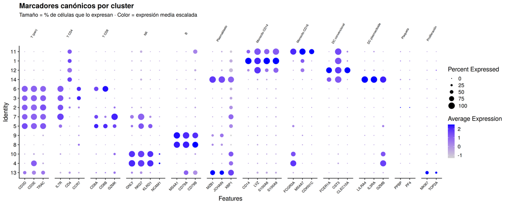

Cada bloque se enciende donde corresponde, con dos trampas a la vista: CD4 da más señal en monocitos (que lo expresan) que en los T CD4, y MZB1/JCHAIN se encienden en plasmablastos y también en las DC plasmacitoides.

## Tipo celular vs estado celular

Distinción conceptual

**Tipo celular**  
Identidad estable, definida por un programa de desarrollo. Un monocito no se convierte en linfocito B.

**Estado celular**  
Condición transitoria superpuesta al tipo: activado, en proliferación, apoptótico, respondiendo a interferón.

**Por qué importa**  
El clustering no distingue entre las dos cosas. Un “cluster nuevo” puede ser un tipo celular no descripto… o los mismos monocitos de al lado, activados.

Señal de alarma

#### ¿Tu cluster está definido por genes de estado?

Si los marcadores principales de un cluster son genes de choque térmico (`HSPA1A`, `HSPB1`), de respuesta temprana (`FOS`, `JUN`, `EGR1`) o de ciclo celular (`MKI67`, `TOP2A`), lo más probable es que estés viendo un **estado**, no un **tipo**.

Y los genes de respuesta temprana suelen ser un artefacto de la disociación del tejido, no biología del donante.

## Programas de estado: ¿qué separa a cada cluster?

En nuestros datos

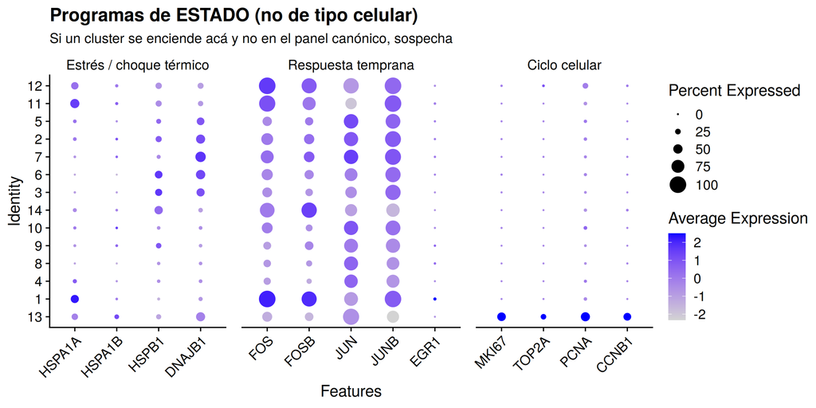

Respuesta temprana

#### Parejo en todos los clusters

`FOS` y `JUNB` aparecen en todos lados, algo más en los mieloides. Es el piso que deja el protocolo: como no distingue a nadie, no define ningún cluster.

Ciclo celular

#### Solo en un cluster: plasmablastos

Es un estado real superpuesto a un tipo: los plasmablastos proliferan. Estado no es sinónimo de artefacto; es algo que no alcanza para definir un tipo.

## Anotación automática

02

## Familias de métodos

Panorama 2026

| Familia | Ejemplos | Qué asume | Cuándo usarlo |
| --- | --- | --- | --- |
| **Correlación con referencia bulk** | SingleR + celldex | Que la referencia contiene el tipo celular que estás mirando | Primera pasada, siempre. Rápido y transparente |
| **Reference mapping** | Azimuth, `FindTransferAnchors` | Que existe una referencia single-cell anotada del tejido | Tejidos bien caracterizados: PBMC, médula ósea, pulmón |
| **Clasificador entrenado** | CellTypist (Python) | Que el modelo vio tipos celulares similares durante el entrenamiento | Inmunología; hay modelos de bajo y alto nivel preentrenados |
| **Consenso** | popV | Que el acuerdo entre métodos mide confianza | Cuando la confianza importa más que la velocidad |
| **Modelos fundacionales** | scGPT, Geneformer | Que el preentrenamiento masivo transfiere a tu dataset | Lectura crítica, más adelante en esta clase |

## celldex ya no se usa como antes

⚠ Cambio de API respecto del material de 2024

**Antes** (forma que todavía circula):

```r
ref <- celldex::BlueprintEncodeData()
```

**Ahora:**

```r
ref <- celldex::fetchReference(
  "blueprint_encode", "2024-02-26"
)
```

`celldex` migró de ExperimentHub a **gypsum**; los accesores viejos quedaron como legado. El cambio no es cosmético: las referencias ahora están **versionadas** y traen las etiquetas mapeadas a Cell Ontology.

Referencias disponibles

#### Nombres para fetchReference()

`blueprint_encode` — inmunes y estromales humanas

`hpca` — Human Primary Cell Atlas, cobertura amplia

`monaco_immune` — la más fina para PBMC

`dice` — Database of Immune Cell Expression

`novershtern_hematopoietic` — hematopoyesis

`immgen`, `mouse_rnaseq` — ratón

## SingleR por célula o por cluster

Decisión práctica

Por célula

#### Anota cada célula de forma independiente

✅ Detecta poblaciones que el clustering fusionó

❌ Más ruidoso: cada célula individual tiene poca información

❌ Sensible al dropout

Por cluster

#### Promedia el perfil del cluster y anota el promedio

✅ Mucho más estable

❌ Hereda todos los errores del clustering

❌ Si un cluster mezcla dos tipos celulares, la etiqueta es de uno solo

**Haz las dos.** Donde coinciden, tienes confianza alta. Donde no coinciden, hay algo concreto que entender: sobre-clusterización, población de transición, doublets, o una referencia que no contiene ese tipo celular.

## SingleR por célula vs por cluster

En nuestros datos

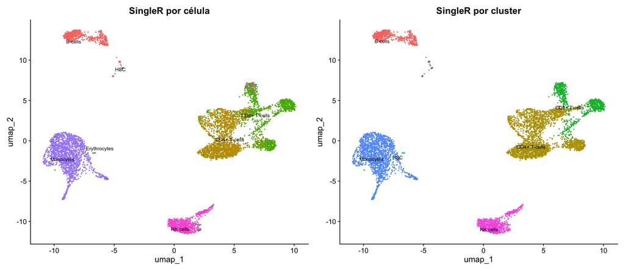

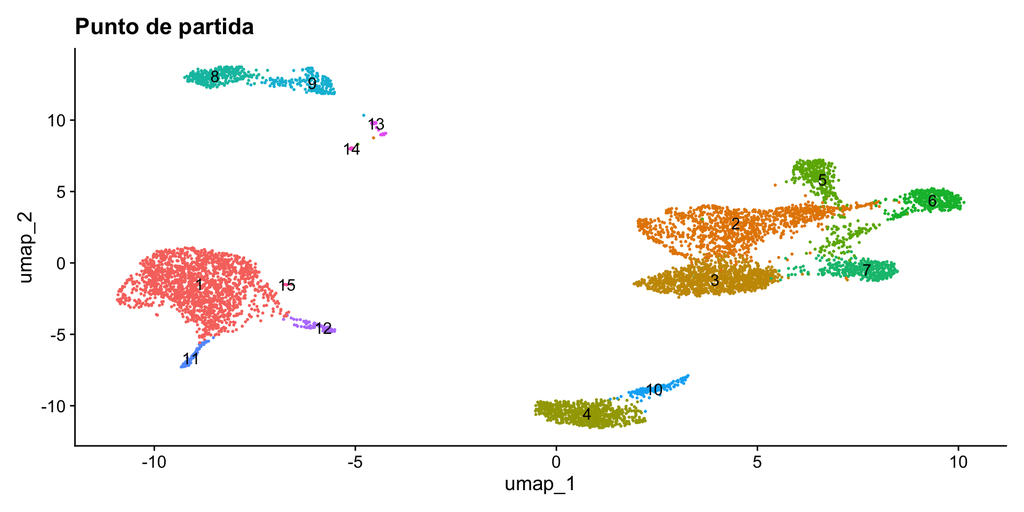

El desacuerdo que importa

#### Cluster 7: ¿CD4 o CD8?

Solo se ve por célula

#### Etiquetas sueltas

`HSC` y `Erythrocytes` en 5 células aisladas: ruido, no poblaciones. Por eso ninguna de las dos vistas alcanza sola.

## La etiqueta no es el resultado: el score sí

Lo que casi nadie mira

Diagnóstico 1

#### plotScoreHeatmap

Los scores de TODAS las etiquetas para cada célula. Una célula bien asignada tiene un score claramente alto para una sola etiqueta; una ambigua, scores parecidos para varias.

Diagnóstico 3

#### pruned.labels

SingleR pone `NA` a las asignaciones de baja confianza. Esos `NA` son **información**, no un error a arreglar. Y casi nunca están repartidos al azar en el UMAP.

Diagnóstico 2

#### delta.next

La diferencia entre el mejor score y la mediana de los demás. Delta chico = asignación poco confiable, aunque la etiqueta se vea razonable.

Diagnóstico 4

#### Tabla cluster × etiqueta

Un cluster coherente concentra sus células en una sola etiqueta. Uno repartido entre dos es una alerta que hay que resolver antes de seguir.

El modo de falla más peligroso: si la referencia **no** contiene el tipo celular que estás mirando, SingleR igual asigna la etiqueta más cercana. El resultado se ve perfectamente razonable.

## Diagnósticos 1 y 2: scores y delta

En nuestros datos

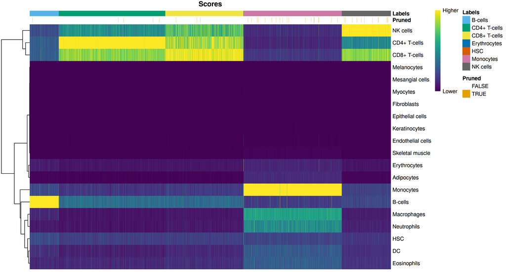

plotScoreHeatmap

#### Una franja amarilla por célula

Monocitos, B y NK: un solo score alto. T CD4 y T CD8: altos los dos a la vez, la frontera más difícil del dataset.

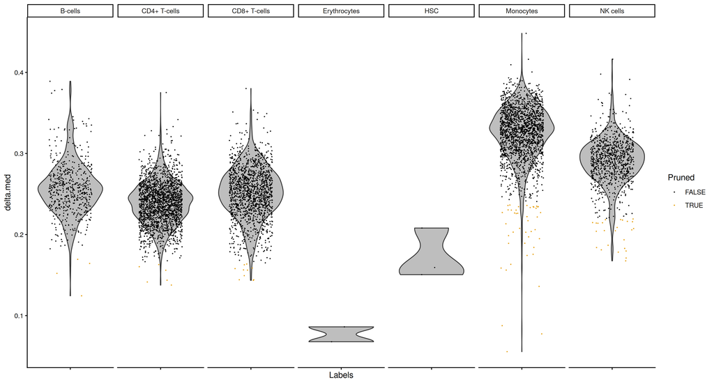

plotDeltaDistribution

#### Los puntos naranjas son los pruned

Quedan en la cola baja de cada violín: delta chico, asignación poco confiable. Así se construye el `NA`.

## Diagnósticos 3 y 4: los NA y la coherencia

En nuestros datos

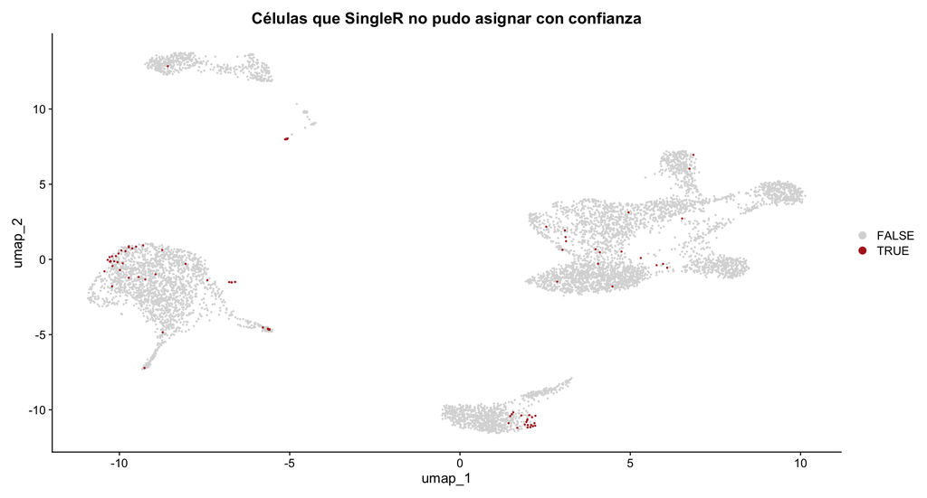

pruned.labels

#### 88 células (1,3 %), no al azar

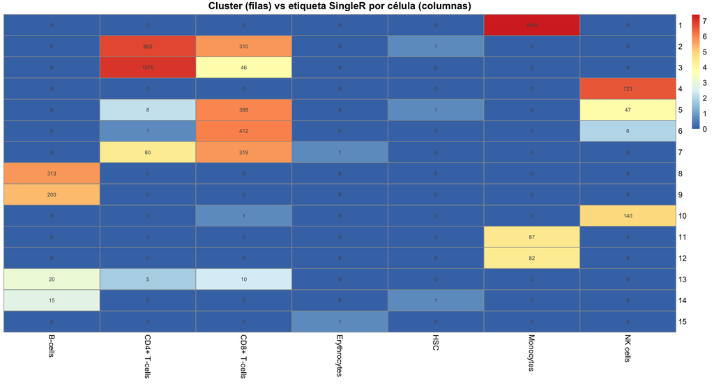

Tabla cluster × etiqueta

#### Las pDC salen como “B-cells”

Blueprint no tiene pDC: asigna lo más parecido y se ve razonable. Es el modo de falla más peligroso, en vivo.

## Reference mapping: proyectar en vez de correlacionar

El tercer método

1 · Anclas

#### FindTransferAnchors

Busca pares de células **mutuamente vecinas** entre referencia y query, en un espacio común.

✅ No compara con un promedio: compara célula con célula

✅ Transfiere cualquier metadato, no solo el tipo celular

❌ Exige una referencia single-cell del MISMO tejido

2 · Transferencia

#### TransferData

Pondera las etiquetas de las células ancla vecinas y devuelve un score por célula.

✅ `prediction.score.max` dice cuán confiable es cada asignación

❌ Si el tipo celular no está en la referencia, igual asigna el más parecido

❌ Un score alto en una referencia equivocada sigue siendo un score alto

**Azimuth** es esta misma metodología, con referencias curadas ya empaquetadas.

## Reference mapping: una mitad predice a la otra

En nuestros datos

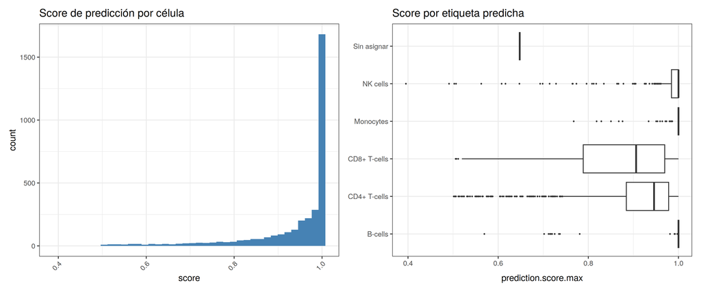

Concordancia

#### 92,8 %

Con las etiquetas por célula de SingleR. El 7 % restante no está repartido al azar: se concentra en T CD8 y T CD4.

Por qué no por cluster

#### Daba 99 % y score 1

Las etiquetas por cluster son una función del grafo de vecinos: transferirlas es trivial y no enseña nada.

## Modelos fundacionales: qué dicen los benchmarks

Lectura crítica

scGPT, Geneformer y sucesores son el tema de moda. Conviene tener una opinión informada.

**La promesa:** preentrenar sobre decenas de millones de células y transferir ese conocimiento a cualquier dataset nuevo, sin entrenamiento adicional (*zero-shot*).

**Lo que muestran los benchmarks independientes 2025–2026.** En anotación de tipo celular *zero-shot* no superan de manera confiable a métodos clásicos que son órdenes de magnitud más baratos. Con *fine-tuning* mejoran, pero entonces ya no son *zero-shot* y compiten en igualdad de condiciones con un clasificador entrenado.

Conclusión para la práctica

#### Seguirlo, no adoptarlo todavía

Es un área de investigación muy activa y vale la pena leerla.

En 2026 **no** reemplaza a SingleR ni a reference mapping para el trabajo de todos los días.

Y es un buen ejercicio de lectura crítica: cuando un método nuevo se presenta como superior, buscar el benchmark independiente, no el del paper original.

## Confundidores

03

Tres artefactos que hacen que una anotación se vea perfecta y sea incorrecta.

## RNA ambiental: la “sopa”

Confundidor 1

Cuando las células se lisan durante la preparación, su ARNm queda libre en la suspensión y se reparte en **todas** las gotas. Cada célula recibe entonces un poco del transcriptoma de sus vecinas muertas.

**Efecto directo sobre la anotación.** Los monocitos expresan `LYZ` a niveles altísimos. La sopa lleva `LYZ` a todas las gotas, y de pronto los linfocitos T “expresan” `LYZ`. Uno concluye que hay una población T atípica. No la hay.

**Diagnóstico rápido, sin instalar nada:** buscar marcadores exclusivos de un tipo celular en los clusters donde no deberían estar.

⚠ Advertencia

#### Corregir no es gratis

Herramientas: **SoupX** (usa gotas vacías), **DecontX** (modelo de mezcla, no las necesita), **CellBender** (red neuronal, la más agresiva).

Los benchmarks de descontaminación publicados en 2026 reportan que algunos métodos **generan conteos artificiales**: agregan señal donde no había.

Recomendación: diagnosticar siempre, corregir solo si el diagnóstico lo justifica, y comparar los resultados con y sin corrección.

## Diagnóstico de la sopa: el piso de LYZ

En nuestros datos

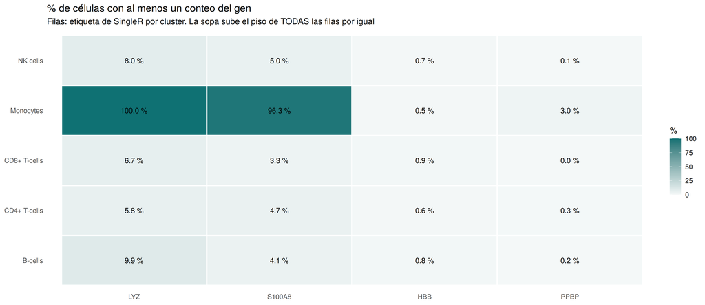

LYZ fuera de los monocitos

#### 6–10 %, parejo

Es el piso que pone la sopa en todas las gotas por igual. Hay sopa, pero poca: PBMC frescas, pocas células lisadas.

PPBP (plaquetas)

#### 3 %, pero solo en monocitos

~0 % en linfocitos. Una señal restringida a un solo tipo no es sopa: aquí son agregados plaqueta–monocito, reales en sangre.

## Doublets remanentes y efectos de lote

Confundidores 2 y 3

Confundidor 2

#### Doublets remanentes

`scDblFinder` no atrapa todo, sobre todo los homotípicos (dos células del mismo tipo).

Un doublet T + monocito aparece como una célula que expresa `CD3E` **y** `CD14`. Es facilísimo bautizarla como “población híbrida novel”.

**→ Regla:** antes de reportar una población que coexpresa marcadores de dos linajes, descarta doublets.

Confundidor 3

#### Efectos de lote

Si el dataset tiene varias muestras y no se integró, los clusters pueden separar por **muestra** en vez de por tipo celular.

Anotar en esa condición produce “tipos celulares” que son lotes. Reaparece en el análisis multimodal con *Bridge Integration*.

**→ Verificación mínima:** grafica el UMAP coloreado por muestra ANTES de anotar nada.

## Ponerle el nombre correcto: ontologías

Interoperabilidad

“Mono”, “monocyte”, “CD14+ Mono”, “Monocito clásico” — si cada laboratorio usa su vocabulario, los datos no se comparan.

La **Cell Ontology (CL)** es un vocabulario controlado, jerárquico y con identificadores estables.

- `CL:0000860` — *classical monocyte*
- `CL:0000624` — *CD4-positive, alpha-beta T cell*

Las referencias de `celldex` ya traen este mapeo (columna `label.ont`). **CZ CELLxGENE exige anotaciones en CL** para depositar un dataset: usar CL desde el principio hace que tu anotación sea reutilizable.

Recurso

#### CellGuide (CZ CELLxGENE)

Por cada tipo celular: definición, marcadores canónicos, marcadores calculados sobre millones de células y posición en la jerarquía CL.

Recurso

#### CELLxGENE Discover

Buscar la expresión de un gen a través de decenas de millones de células anotadas.

Recurso

#### Human Cell Atlas

Datos de referencia organizados por tejido y órgano.

## L1, L2, L3: ¿a qué resolución anotar?

Niveles de anotación

L1 · Linaje

#### Unos 8 tipos grandes (Azimuth PBMC, celltype.l1)

B · T CD4 · T CD8 · otras T · NK · monocitos · DC · otras. Blueprint (`label.main`) anota cerca de este nivel.

L2 · Subtipo

#### Unas 30 etiquetas: acá vive nuestra anotación final

Naive vs memoria, CD14 vs CD16, cDC vs pDC, NK CD56bright, MAIT, plasmablasto. Monaco (`label.fine`) anota en este nivel.

L3 · Subtipo fino y estado

#### Más de 50 etiquetas: con solo ARN no se sostiene

Central vs efector memoria, Treg, γδ, cDC1 vs cDC2… Hace falta una referencia más fina, más células o proteína.

Más fino, menos seguro

#### La confianza depende del nivel

Los métodos coinciden casi siempre en el compartimento (T, B, NK, mieloide). Los desacuerdos de nuestra tabla aparecen dentro de él: CD4 vs CD8, MAIT vs CD8, cDC vs monocito.

Regla práctica

#### Reporta el nivel que puedas defender

Monaco propone γδ o “exhausted B”; nos quedamos en L2 porque no lo podemos sostener. Y para comparar métodos, llévalos al mismo nivel.

## La anotación final

04

Evidencia convergente y una confianza que cualquiera puede auditar.

## Qué dice cada método, cluster por cluster

Evidencia convergente

| Cl. | Blueprint · cluster | Blueprint · células | Monaco · principal | Cluster = sus células | Coherencia ≥ 80 % | Blueprint = Monaco | Confianza |
| --- | --- | --- | --- | --- | --- | --- | --- |
| 1 | Monocytes | Monocytes | Monocytes | ✓ | ✓ | ✓ | alta |
| 2 | CD4+ T-cells | CD4+ T-cells | CD4+ T cells | ✓ | ✗ | ✓ | media |
| 3 | CD4+ T-cells | CD4+ T-cells | CD4+ T cells | ✓ | ✓ | ✓ | alta |
| 4 | NK cells | NK cells | NK cells | ✓ | ✓ | ✓ | alta |
| 5 | CD8+ T-cells | CD8+ T-cells | T cells | ✓ | ✓ | ✗ | media |
| 6 | CD8+ T-cells | CD8+ T-cells | T cells | ✓ | ✓ | ✗ | media |
| 7 | CD4+ T-cells | CD8+ T-cells | CD8+ T cells | ✗ | ✗ | ✗ | **baja** |
| 8 | B-cells | B-cells | B cells | ✓ | ✓ | ✓ | alta |
| 9 | B-cells | B-cells | B cells | ✓ | ✓ | ✓ | alta |
| 10 | NK cells | NK cells | NK cells | ✓ | ✓ | ✓ | alta |
| 11 | Monocytes | Monocytes | Monocytes | ✓ | ✓ | ✓ | alta |
| 12 | Monocytes | Monocytes | Dendritic cells | ✓ | ✓ | ✗ | media |
| 13 | NA | B-cells | B cells | ✗ | ✗ | ✗ | **baja** |
| 14 | NA | B-cells | Dendritic cells | ✗ | ✗ | ✗ | **baja** |
| 15 | HSC | Erythrocytes | Progenitors | ✗ | ✗ | ✗ | **baja** |

**Regla:** un punto por cada comprobación — el cluster coincide con la mayoría de sus células · ≥ 80 % de coherencia · Blueprint = Monaco en el tipo principal. 3 = alta · 2 = media · 0–1 = baja.

## Quince etiquetas, cada una con su confianza

La anotación final

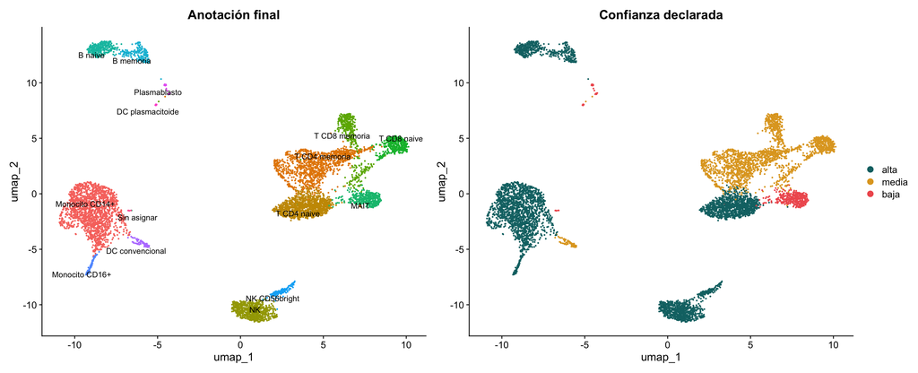

Cada etiqueta lleva su identificador de Cell Ontology (p. ej. T CD8 naive = CL:0000900) y todo queda en `results/clase3_anotacion_por_cluster.csv`. La zona roja del compartimento T es la que el jueves vamos a contrastar con la proteína.

## Ocho cosas

Síntesis

1. **La anotación es una hipótesis.** Se sostiene con evidencia convergente.
2. **Los marcadores canónicos vienen de la proteína**; el ARNm es un proxy imperfecto.
3. **`celldex` cambió de API:** `fetchReference(nombre, versión)`. Referencias versionadas y con Cell Ontology.
4. **Nunca mires solo la etiqueta:** score, delta y `pruned.labels` son parte del resultado. Un `NA` es información.
5. **Anota por célula y por cluster.** Donde no coinciden, hay algo que entender.
6. **El RNA ambiental produce anotaciones falsas.** Diagnostica siempre; corrige con cuidado.
7. **Declara la confianza con una regla explícita.** “Baja” no es “incorrecta”: es donde los métodos no convergen.
8. **Usa vocabulario controlado** para que tu anotación sirva más allá de tu propio análisis.

El jueves medimos la proteína en estas mismas células — y la primera zona que vamos a mirar es la que hoy quedó en rojo.

Inicio